# Logistic Regression

## Topics

### Part 1: Predicting a Continuous Response

```r
col_names = c('id','ri','na','mg','al','si','k','ca','ba','fe','glass_type')
glass<- read.csv('http://archive.ics.uci.edu/ml/machine-learning-databases/glass/glass.data',col.names =col_names )
head(glass)
```

|  | id | ri | na | mg | al | si | k | ca | ba | fe | glass_type |
| --- | --- | --- | --- | --- | --- | --- | --- | --- | --- | --- | --- |
| 1 | 2 | 1.51761 | 13.89 | 3.60 | 1.36 | 72.73 | 0.48 | 7.83 | 0 | 0.00 | 1 |
| 2 | 3 | 1.51618 | 13.53 | 3.55 | 1.54 | 72.99 | 0.39 | 7.78 | 0 | 0.00 | 1 |
| 3 | 4 | 1.51766 | 13.21 | 3.69 | 1.29 | 72.61 | 0.57 | 8.22 | 0 | 0.00 | 1 |
| 4 | 5 | 1.51742 | 13.27 | 3.62 | 1.24 | 73.08 | 0.55 | 8.07 | 0 | 0.00 | 1 |
| 5 | 6 | 1.51596 | 12.79 | 3.61 | 1.62 | 72.97 | 0.64 | 8.07 | 0 | 0.26 | 1 |
| 6 | 7 | 1.51743 | 13.30 | 3.60 | 1.14 | 73.09 | 0.58 | 8.17 | 0 | 0.00 | 1 |

**Question:** Pretend that we want to predict *ri*, and our only feature is *al*. How could we do it using machine learning?

**Answer:** We could frame it as a regression problem, and use a linear regression model with *al* as the only feature and *ri* as the response.

**Question:** How would we visualize this model?

**Answer:** Create a scatter plot with *al* on the x-axis and *ri* on the y-axis, and draw the line of best fit.

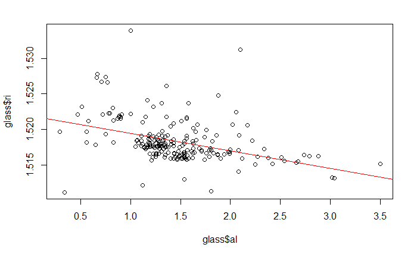

```r
plot(glass$al, glass$ri)
abline(lm(glass$ri~glass$al), col="red")
```

```r
# linear regression
linear.reg<- lm(ri~al,data = glass)
glass$ri_pred<- predict(linear.reg)
head(glass)
```

|  | id | ri | na | mg | al | si | k | ca | ba | fe | glass_type | ri_pred |
| --- | --- | --- | --- | --- | --- | --- | --- | --- | --- | --- | --- | --- |
| 1 | 2 | 1.51761 | 13.89 | 3.60 | 1.36 | 72.73 | 0.48 | 7.83 | 0 | 0.00 | 1 | 1.518566 |
| 2 | 3 | 1.51618 | 13.53 | 3.55 | 1.54 | 72.99 | 0.39 | 7.78 | 0 | 0.00 | 1 | 1.518123 |
| 3 | 4 | 1.51766 | 13.21 | 3.69 | 1.29 | 72.61 | 0.57 | 8.22 | 0 | 0.00 | 1 | 1.518739 |
| 4 | 5 | 1.51742 | 13.27 | 3.62 | 1.24 | 73.08 | 0.55 | 8.07 | 0 | 0.00 | 1 | 1.518862 |
| 5 | 6 | 1.51596 | 12.79 | 3.61 | 1.62 | 72.97 | 0.64 | 8.07 | 0 | 0.26 | 1 | 1.517925 |
| 6 | 7 | 1.51743 | 13.30 | 3.60 | 1.14 | 73.09 | 0.58 | 8.17 | 0 | 0.00 | 1 | 1.519109 |

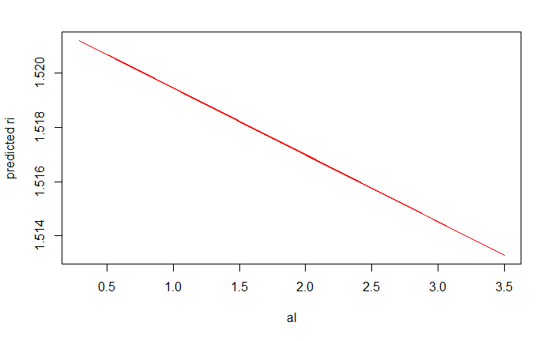

```r
plot(glass$al, glass$ri_pred, col="red", type="l", xlab = "al", ylab="predicted ri")
```

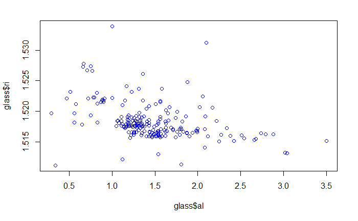

```r
#plot(glass$al, glass$ri_pred, col="red", type="l", xlab = "al", ylab="predicted ri")
plot(glass$al, glass$ri, col="blue")
```

```r
#abline(lm(glass$ri, glass$ri_pred, col="red")
```

```r
# compute prediction for al=2 using the equation
linear.reg$coefficients[1] + linear.reg$coefficients[2]*2
```

```
(Intercept)
   1.516988
```

```r
predict(linear.reg, data.frame(al=c(2)))
```

```
       1
1.516988
```

```r
 linear.reg$coefficients
```

```
 (Intercept)           al
 1.521919989 -0.002465897
```

**Interpretation:** A 1 unit increase in ‘al’ is associated with a 0.0025 unit decrease in ‘ri’.

### Part 2: Predicting a Categorical Response

```r
glass  %>%  group_by(glass_type) %>% summarise(count=n())
```

| glass_type | count |
| --- | --- |
| 1 | 69 |
| 2 | 76 |
| 3 | 17 |
| 5 | 13 |
| 6 | 9 |
| 7 | 29 |

```r
# types 1, 2, 3 are window glass
# types 5, 6, 7 are household glass
glass<- glass %>% mutate(household= if_else(glass_type <4,0,1))
head(glass)
```

|  | id | ri | na | mg | al | si | k | ca | ba | fe | glass_type | ri_pred | household |
| --- | --- | --- | --- | --- | --- | --- | --- | --- | --- | --- | --- | --- | --- |
| 1 | 2 | 1.51761 | 13.89 | 3.60 | 1.36 | 72.73 | 0.48 | 7.83 | 0 | 0.00 | 1 | 1.518566 | 0 |
| 2 | 3 | 1.51618 | 13.53 | 3.55 | 1.54 | 72.99 | 0.39 | 7.78 | 0 | 0.00 | 1 | 1.518123 | 0 |
| 3 | 4 | 1.51766 | 13.21 | 3.69 | 1.29 | 72.61 | 0.57 | 8.22 | 0 | 0.00 | 1 | 1.518739 | 0 |
| 4 | 5 | 1.51742 | 13.27 | 3.62 | 1.24 | 73.08 | 0.55 | 8.07 | 0 | 0.00 | 1 | 1.518862 | 0 |
| 5 | 6 | 1.51596 | 12.79 | 3.61 | 1.62 | 72.97 | 0.64 | 8.07 | 0 | 0.26 | 1 | 1.517925 | 0 |
| 6 | 7 | 1.51743 | 13.30 | 3.60 | 1.14 | 73.09 | 0.58 | 8.17 | 0 | 0.00 | 1 | 1.519109 | 0 |

Let’s change our task, so that we’re predicting household using *al*. Let’s visualize the relationship to figure out how to do this:

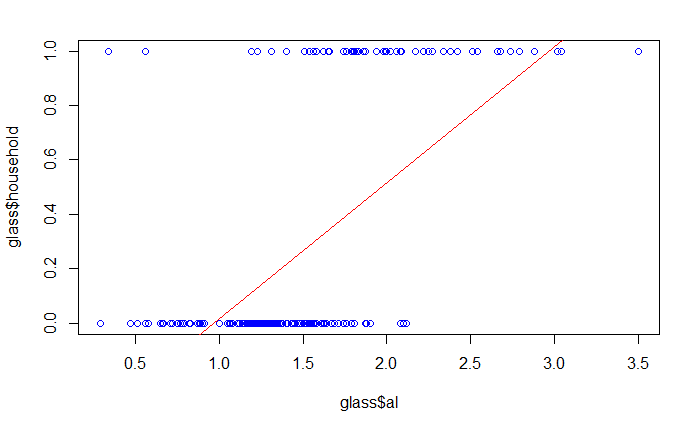

```r
plot(glass$al, glass$household, col="blue")
abline(lm(glass$household~glass$al), col="red")
```

Let’s draw a **regression line**, like we did before:

```r
# linear regression
linear.reg<- lm(household~al ,data = glass)
glass$household_pred<- predict(linear.reg)
head(glass)
```

|  | id | ri | na | mg | al | si | k | ca | ba | fe | glass_type | ri_pred | household | household_pred |
| --- | --- | --- | --- | --- | --- | --- | --- | --- | --- | --- | --- | --- | --- | --- |
| 1 | 2 | 1.51761 | 13.89 | 3.60 | 1.36 | 72.73 | 0.48 | 7.83 | 0 | 0.00 | 1 | 1.518566 | 0 | 0.19610892 |
| 2 | 3 | 1.51618 | 13.53 | 3.55 | 1.54 | 72.99 | 0.39 | 7.78 | 0 | 0.00 | 1 | 1.518123 | 0 | 0.28624370 |
| 3 | 4 | 1.51766 | 13.21 | 3.69 | 1.29 | 72.61 | 0.57 | 8.22 | 0 | 0.00 | 1 | 1.518739 | 0 | 0.16105650 |
| 4 | 5 | 1.51742 | 13.27 | 3.62 | 1.24 | 73.08 | 0.55 | 8.07 | 0 | 0.00 | 1 | 1.518862 | 0 | 0.13601906 |
| 5 | 6 | 1.51596 | 12.79 | 3.61 | 1.62 | 72.97 | 0.64 | 8.07 | 0 | 0.26 | 1 | 1.517925 | 0 | 0.32630361 |
| 6 | 7 | 1.51743 | 13.30 | 3.60 | 1.14 | 73.09 | 0.58 | 8.17 | 0 | 0.00 | 1 | 1.519109 | 0 | 0.08594418 |

```r
glass<- glass %>% mutate(household_pred_class= if_else(household_pred < 0.5,0,1))
head(glass)
```

|  | id | ri | na | mg | al | si | k | ca | ba | fe | glass_type | ri_pred | household | household_pred | household_pred_class |
| --- | --- | --- | --- | --- | --- | --- | --- | --- | --- | --- | --- | --- | --- | --- | --- |
| 1 | 2 | 1.51761 | 13.89 | 3.60 | 1.36 | 72.73 | 0.48 | 7.83 | 0 | 0.00 | 1 | 1.518566 | 0 | 0.19610892 | 0 |
| 2 | 3 | 1.51618 | 13.53 | 3.55 | 1.54 | 72.99 | 0.39 | 7.78 | 0 | 0.00 | 1 | 1.518123 | 0 | 0.28624370 | 0 |
| 3 | 4 | 1.51766 | 13.21 | 3.69 | 1.29 | 72.61 | 0.57 | 8.22 | 0 | 0.00 | 1 | 1.518739 | 0 | 0.16105650 | 0 |
| 4 | 5 | 1.51742 | 13.27 | 3.62 | 1.24 | 73.08 | 0.55 | 8.07 | 0 | 0.00 | 1 | 1.518862 | 0 | 0.13601906 | 0 |
| 5 | 6 | 1.51596 | 12.79 | 3.61 | 1.62 | 72.97 | 0.64 | 8.07 | 0 | 0.26 | 1 | 1.517925 | 0 | 0.32630361 | 0 |
| 6 | 7 | 1.51743 | 13.30 | 3.60 | 1.14 | 73.09 | 0.58 | 8.17 | 0 | 0.00 | 1 | 1.519109 | 0 | 0.08594418 | 0 |

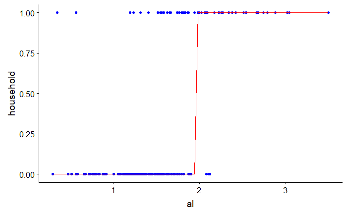

```r
ggplot(glass, aes(x=al, y=household)) + geom_point(col="blue") + geom_line(aes(x= al, y=household_pred_class) , col="red")
```

### Part 3: Using Logistic Regression

Logistic regression can do what we just did:

```r
logistic.reg<- glm(household~al, data = glass, family = "binomial")
glass$household_pred_class<-if_else(predict(logistic.reg, type = "response") >0.5,1,0)
```

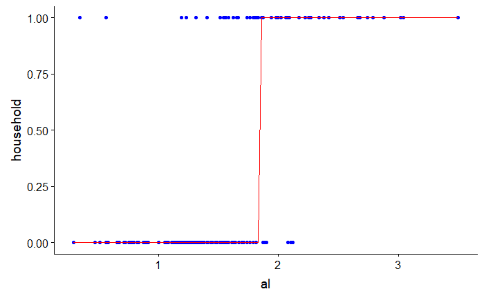

```r
# plot the class predictions
ggplot(glass, aes(x=al, y=household)) + geom_point(col="blue") + geom_line(aes(x= al, y=household_pred_class) , col="red")
```

What if we wanted the predicted probabilities instead of just the class predictions, to understand how confident we are in a given prediction?

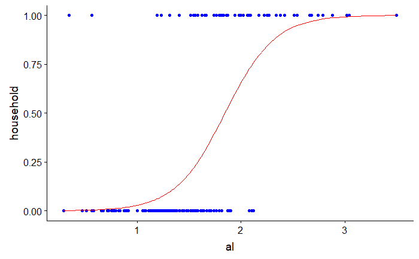

```r
glass$household_pred_prob<-predict(logistic.reg, type = "response")
# plot the class probabilities
ggplot(glass, aes(x=al, y=household)) + geom_point(col="blue") + geom_line(aes(x= al, y=household_pred_prob) , col="red")
```

```r
# examine some example predictions
predict(logistic.reg, data.frame(al=c(1)), type = "response")
```

```
         1
0.02858908
```

```r
predict(logistic.reg, data.frame(al=c(2)), type = "response")
```

```
        1
0.6559604
```

```r
predict(logistic.reg, data.frame(al=c(3)), type = "response")
```

```
        1
0.9919692
```

Indicates the predicted probability of class 1.

### Part 4: Probability, odds, e, log, log-odds

$$probability = \frac {one\ outcome} {all\ outcomes}$$

$$odds = \frac {one\ outcome} {all\ other\ outcomes}$$

Examples:

Dice roll of 1: probability = 1/6, odds = 1/5 Even dice roll: probability = 3/6, odds = 3/3 = 1 Dice roll less than 5: probability = 4/6, odds = 4/2 = 2

$$odds = \frac {probability} {1 - probability}$$

$$probability = \frac {odds} {1 + odds}$$

```r
# create a table of probability versus odds
prob<- c(0.1, .2, .3, .4, .5, .6, .7, .8, .9)
df<- data.frame(prob)
df$odds<- df$prob/(1-df$prob)
head(df)
```

[output not shown]

What is e? It is the base rate of growth shared by all continually growing processes

```r
exp(1)
```

[output not shown]

What is a (natural) log? It gives you the time needed to reach a certain level of growth

```r
log(exp(1))
```

[output not shown]

```r
df$logodds<- log(df$odds)
df
```

[output not shown]

### Part 5: What is Logistic Regression?

**Linear regression:** continuous response is modeled as a linear combination of the features:

$$y=(\beta_0 + \beta_1x)$$

**Logistic regression:** log-odds of a categorical response being “true” (1) is modeled as a linear combination of the features:

$$\log \left({p\over 1-p}\right) = \beta_0 + \beta_1x$$
This is called the **logit function.**

Probability is sometimes written as pi:

$$\log \left({\pi\over 1-\pi}\right) = \beta_0 + \beta_1x$$
The equation can be rearranged into the **logistic function:**

$$\pi = \frac{e^{\beta_0 + \beta_1x}} {1 + e^{\beta_0 + \beta_1x}}$$

In other words:

Logistic regression outputs the **probabilities of a specific class** Those probabilities can be converted into **class predictions** The **logistic function** has some nice properties:

Takes on an “s” shape Output is bounded by 0 and 1

### Part 6: Comparing Logistic Regression with Other Models

**Advantages** of logistic regression:

1. Highly interpretable (if you remember how)
2. Model training and prediction are fast
3. No tuning is required (excluding regularization)
4. Features don’t need scaling
5. Can perform well with a small number of observations
6. Outputs well-calibrated predicted probabilities

**Disadvantages** of logistic regression:

1. Presumes a linear relationship between the features and the log-odds of the response
2. Performance is (generally) not competitive with the best supervised learning methods
3. Can’t automatically learn feature interactions